# GooGle_project

### Table of Content:-

1. Import Libraries.
2. Read dataset.
3. Show abreif Show a brief of the dataframe.
4. Data Exploration.
5. Data Cleaning.
6. EDA (Exploratory Data Analysis).
7. Conclusion.

## 1. Import Libraries:-

```python
import pandas as pd
import numpy as np
import matplotlib.pyplot as plt
import seaborn as sns
import missingno as misno
```

## 2. Read dataset:-

```python
## dataset (Google App Store) will be known as GAS
GAS=pd.read_csv(r'C:\Users\dell\Desktop\DATA_ SCIENCE\data_sets\kaggleDS\google app store\google.csv')
```

## 3. Show abreif Show a brief of the dataframe:-

```python
## Dataset Called GAS (Google App Store)
## show first 5 rows
GAS.head()
```

|  | App | Category | Rating | Reviews | Size | Installs | Type | Price | Content Rating | Genres | Last Updated | Current Ver | Android Ver |
| --- | --- | --- | --- | --- | --- | --- | --- | --- | --- | --- | --- | --- | --- |
| 0 | Photo Editor & Candy Camera & Grid & ScrapBook | ART_AND_DESIGN | 4.1 | 159 | 19M | 10,000+ | Free | 0 | Everyone | Art & Design | January 7, 2018 | 1.0.0 | 4.0.3 and up |
| 1 | Coloring book moana | ART_AND_DESIGN | 3.9 | 967 | 14M | 500,000+ | Free | 0 | Everyone | Art & Design;Pretend Play | January 15, 2018 | 2.0.0 | 4.0.3 and up |
| 2 | U Launcher Lite – FREE Live Cool Themes, Hide ... | ART_AND_DESIGN | 4.7 | 87510 | 8.7M | 5,000,000+ | Free | 0 | Everyone | Art & Design | August 1, 2018 | 1.2.4 | 4.0.3 and up |
| 3 | Sketch - Draw & Paint | ART_AND_DESIGN | 4.5 | 215644 | 25M | 50,000,000+ | Free | 0 | Teen | Art & Design | June 8, 2018 | Varies with device | 4.2 and up |
| 4 | Pixel Draw - Number Art Coloring Book | ART_AND_DESIGN | 4.3 | 967 | 2.8M | 100,000+ | Free | 0 | Everyone | Art & Design;Creativity | June 20, 2018 | 1.1 | 4.4 and up |

```python
## Show last 5 rows
GAS.tail()
```

|  | App | Category | Rating | Reviews | Size | Installs | Type | Price | Content Rating | Genres | Last Updated | Current Ver | Android Ver |
| --- | --- | --- | --- | --- | --- | --- | --- | --- | --- | --- | --- | --- | --- |
| 10836 | Sya9a Maroc - FR | FAMILY | 4.5 | 38 | 53M | 5,000+ | Free | 0 | Everyone | Education | July 25, 2017 | 1.48 | 4.1 and up |
| 10837 | Fr. Mike Schmitz Audio Teachings | FAMILY | 5.0 | 4 | 3.6M | 100+ | Free | 0 | Everyone | Education | July 6, 2018 | 1.0 | 4.1 and up |
| 10838 | Parkinson Exercices FR | MEDICAL | NaN | 3 | 9.5M | 1,000+ | Free | 0 | Everyone | Medical | January 20, 2017 | 1.0 | 2.2 and up |
| 10839 | The SCP Foundation DB fr nn5n | BOOKS_AND_REFERENCE | 4.5 | 114 | Varies with device | 1,000+ | Free | 0 | Mature 17+ | Books & Reference | January 19, 2015 | Varies with device | Varies with device |
| 10840 | iHoroscope - 2018 Daily Horoscope & Astrology | LIFESTYLE | 4.5 | 398307 | 19M | 10,000,000+ | Free | 0 | Everyone | Lifestyle | July 25, 2018 | Varies with device | Varies with device |

## 4. Data Exploration:-

```python
## Get shape of data
GAS.shape            # (Row, Column)
```

```
(10841, 13)
```

```python
GAS.columns  # columns in dataset
```

```
Index(['App', 'Category', 'Rating', 'Reviews', 'Size', 'Installs', 'Type',
       'Price', 'Content Rating', 'Genres', 'Last Updated', 'Current Ver',
       'Android Ver'],
      dtype='object')
```

```python
## Get More information about data
GAS.info()
```

```
<class 'pandas.core.frame.DataFrame'>
RangeIndex: 10841 entries, 0 to 10840
Data columns (total 13 columns):
 #   Column          Non-Null Count  Dtype
---  ------          --------------  -----
 0   App             10841 non-null  object
 1   Category        10841 non-null  object
 2   Rating          9367 non-null   float64
 3   Reviews         10841 non-null  object
 4   Size            10841 non-null  object
 5   Installs        10841 non-null  object
 6   Type            10840 non-null  object
 7   Price           10841 non-null  object
 8   Content Rating  10840 non-null  object
 9   Genres          10841 non-null  object
 10  Last Updated    10841 non-null  object
 11  Current Ver     10833 non-null  object
 12  Android Ver     10838 non-null  object
dtypes: float64(1), object(12)
memory usage: 1.1+ MB
```

##### There are 10841 rows , Datatypes are object except Rating is Float64

```python
## More Statiscal inforamtion
GAS.describe()
```

|  | Rating |
| --- | --- |
| count | 9367.000000 |
| mean | 4.193338 |
| std | 0.537431 |
| min | 1.000000 |
| 25% | 4.000000 |
| 50% | 4.300000 |
| 75% | 4.500000 |
| max | 19.000000 |

```python
## Check null values
GAS.isna().any()
```

```
App               False
Category          False
Rating             True
Reviews           False
Size              False
Installs          False
Type               True
Price             False
Content Rating     True
Genres            False
Last Updated      False
Current Ver        True
Android Ver        True
dtype: bool
```

###### That mean ( Rating, Type, Content Rating, current Ver, Andoried Ver) have missing values

```python
## check the number of the missing values
GAS.isna().sum()
```

```
App                  0
Category             0
Rating            1474
Reviews              0
Size                 0
Installs             0
Type                 1
Price                0
Content Rating       1
Genres               0
Last Updated         0
Current Ver          8
Android Ver          3
dtype: int64
```

```python
## check the percentage of the missing values
GAS.isna().sum()/100
```

```
App                0.00
Category           0.00
Rating            14.74
Reviews            0.00
Size               0.00
Installs           0.00
Type               0.01
Price              0.00
Content Rating     0.01
Genres             0.00
Last Updated       0.00
Current Ver        0.08
Android Ver        0.03
dtype: float64
```

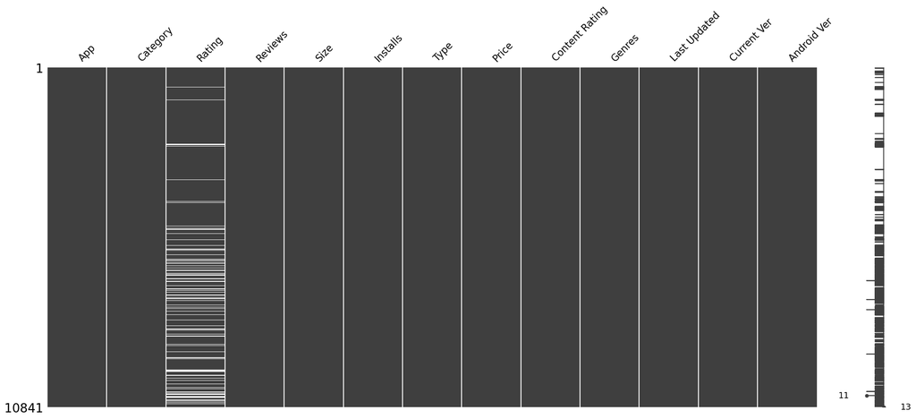

```python
misno.matrix(GAS)  ## in the column of Rating there are white lines that mean missing values
```

###### It shows the missing values in Rating

## 4. Data Cleaning:-

```python
## show the number of null values of (Rating)
GAS['Rating'].isna().sum()
```

```
1474
```

```python
## show the dataframe which is have missing values
GAS[GAS['Rating'].isna()]
```

|  | App | Category | Rating | Reviews | Size | Installs | Type | Price | Content Rating | Genres | Last Updated | Current Ver | Android Ver |
| --- | --- | --- | --- | --- | --- | --- | --- | --- | --- | --- | --- | --- | --- |
| 23 | Mcqueen Coloring pages | ART_AND_DESIGN | NaN | 61 | 7.0M | 100,000+ | Free | 0 | Everyone | Art & Design;Action & Adventure | March 7, 2018 | 1.0.0 | 4.1 and up |
| 113 | Wrinkles and rejuvenation | BEAUTY | NaN | 182 | 5.7M | 100,000+ | Free | 0 | Everyone 10+ | Beauty | September 20, 2017 | 8.0 | 3.0 and up |
| 123 | Manicure - nail design | BEAUTY | NaN | 119 | 3.7M | 50,000+ | Free | 0 | Everyone | Beauty | July 23, 2018 | 1.3 | 4.1 and up |
| 126 | Skin Care and Natural Beauty | BEAUTY | NaN | 654 | 7.4M | 100,000+ | Free | 0 | Teen | Beauty | July 17, 2018 | 1.15 | 4.1 and up |
| 129 | Secrets of beauty, youth and health | BEAUTY | NaN | 77 | 2.9M | 10,000+ | Free | 0 | Mature 17+ | Beauty | August 8, 2017 | 2.0 | 2.3 and up |
| ... | ... | ... | ... | ... | ... | ... | ... | ... | ... | ... | ... | ... | ... |
| 10824 | Cardio-FR | MEDICAL | NaN | 67 | 82M | 10,000+ | Free | 0 | Everyone | Medical | July 31, 2018 | 2.2.2 | 4.4 and up |
| 10825 | Naruto & Boruto FR | SOCIAL | NaN | 7 | 7.7M | 100+ | Free | 0 | Teen | Social | February 2, 2018 | 1.0 | 4.0 and up |
| 10831 | payermonstationnement.fr | MAPS_AND_NAVIGATION | NaN | 38 | 9.8M | 5,000+ | Free | 0 | Everyone | Maps & Navigation | June 13, 2018 | 2.0.148.0 | 4.0 and up |
| 10835 | FR Forms | BUSINESS | NaN | 0 | 9.6M | 10+ | Free | 0 | Everyone | Business | September 29, 2016 | 1.1.5 | 4.0 and up |
| 10838 | Parkinson Exercices FR | MEDICAL | NaN | 3 | 9.5M | 1,000+ | Free | 0 | Everyone | Medical | January 20, 2017 | 1.0 | 2.2 and up |

1474 rows × 13 columns

```python
# Delete all rows which is have missing values of Rating column
GAS.dropna(subset=['Rating'] , axis=0, inplace = True)
```

```python
## check missng values after deleting
GAS['Rating'].isna().sum()
```

```
0
```

```python
# Delete all rows which is have missing values of Type column
GAS.dropna(subset=['Type'] , axis=0, inplace = True)
```

```python
## check missng values after deleting
GAS['Type'].isna().sum()
```

```
0
```

###### That mean no missing values , But there are columns we donot need so i will delete them.

```python
# Delete columns which is not helpful for us

x = GAS[['Content Rating', 'Current Ver', 'Android Ver']]
GAS.drop(x.columns.tolist(), axis=1, inplace=True)
```

```python
## show the first 5 rows after deleting columns
GAS.head()
```

|  | App | Category | Rating | Reviews | Size | Installs | Type | Price | Genres | Last Updated |
| --- | --- | --- | --- | --- | --- | --- | --- | --- | --- | --- |
| 0 | Photo Editor & Candy Camera & Grid & ScrapBook | ART_AND_DESIGN | 4.1 | 159 | 19M | 10,000+ | Free | 0 | Art & Design | January 7, 2018 |
| 1 | Coloring book moana | ART_AND_DESIGN | 3.9 | 967 | 14M | 500,000+ | Free | 0 | Art & Design;Pretend Play | January 15, 2018 |
| 2 | U Launcher Lite – FREE Live Cool Themes, Hide ... | ART_AND_DESIGN | 4.7 | 87510 | 8.7M | 5,000,000+ | Free | 0 | Art & Design | August 1, 2018 |
| 3 | Sketch - Draw & Paint | ART_AND_DESIGN | 4.5 | 215644 | 25M | 50,000,000+ | Free | 0 | Art & Design | June 8, 2018 |
| 4 | Pixel Draw - Number Art Coloring Book | ART_AND_DESIGN | 4.3 | 967 | 2.8M | 100,000+ | Free | 0 | Art & Design;Creativity | June 20, 2018 |

## 5. EDA (Exploratory Data Analysis):-

### 5.1- What is the categories in dataset?

```python
## show all Categories
GAS['Category'].unique()
```

```
array(['ART_AND_DESIGN', 'AUTO_AND_VEHICLES', 'BEAUTY',
       'BOOKS_AND_REFERENCE', 'BUSINESS', 'COMICS', 'COMMUNICATION',
       'DATING', 'EDUCATION', 'ENTERTAINMENT', 'EVENTS', 'FINANCE',
       'FOOD_AND_DRINK', 'HEALTH_AND_FITNESS', 'HOUSE_AND_HOME',
       'LIBRARIES_AND_DEMO', 'LIFESTYLE', 'GAME', 'FAMILY', 'MEDICAL',
       'SOCIAL', 'SHOPPING', 'PHOTOGRAPHY', 'SPORTS', 'TRAVEL_AND_LOCAL',
       'TOOLS', 'PERSONALIZATION', 'PRODUCTIVITY', 'PARENTING', 'WEATHER',
       'VIDEO_PLAYERS', 'NEWS_AND_MAGAZINES', 'MAPS_AND_NAVIGATION'],
      dtype=object)
```

```python
## show the number Categories
GAS['Category'].nunique()
```

```
33
```

### 5.2- What is the top 5 categories?

```python
A = GAS['Category'].value_counts().index
A
```

```
Index(['FAMILY', 'GAME', 'TOOLS', 'PRODUCTIVITY', 'MEDICAL', 'COMMUNICATION',
       'FINANCE', 'SPORTS', 'PHOTOGRAPHY', 'PERSONALIZATION', 'LIFESTYLE',
       'BUSINESS', 'HEALTH_AND_FITNESS', 'SOCIAL', 'SHOPPING',
       'NEWS_AND_MAGAZINES', 'TRAVEL_AND_LOCAL', 'DATING',
       'BOOKS_AND_REFERENCE', 'VIDEO_PLAYERS', 'EDUCATION', 'ENTERTAINMENT',
       'MAPS_AND_NAVIGATION', 'FOOD_AND_DRINK', 'HOUSE_AND_HOME', 'WEATHER',
       'AUTO_AND_VEHICLES', 'LIBRARIES_AND_DEMO', 'ART_AND_DESIGN', 'COMICS',
       'PARENTING', 'EVENTS', 'BEAUTY'],
      dtype='object', name='Category')
```

```python
B = GAS['Category'].value_counts().values
B
```

```
array([1747, 1097,  734,  351,  350,  328,  323,  319,  317,  314,  314,
        303,  297,  259,  238,  233,  226,  195,  178,  160,  155,  149,
        124,  109,   76,   75,   73,   65,   62,   58,   50,   45,   42],
      dtype=int64)
```

```python
## show each Category and it is number
GAS['Category'].value_counts()
```

```
Category
FAMILY                 1747
GAME                   1097
TOOLS                   734
PRODUCTIVITY            351
MEDICAL                 350
COMMUNICATION           328
FINANCE                 323
SPORTS                  319
PHOTOGRAPHY             317
PERSONALIZATION         314
LIFESTYLE               314
BUSINESS                303
HEALTH_AND_FITNESS      297
SOCIAL                  259
SHOPPING                238
NEWS_AND_MAGAZINES      233
TRAVEL_AND_LOCAL        226
DATING                  195
BOOKS_AND_REFERENCE     178
VIDEO_PLAYERS           160
EDUCATION               155
ENTERTAINMENT           149
MAPS_AND_NAVIGATION     124
FOOD_AND_DRINK          109
HOUSE_AND_HOME           76
WEATHER                  75
AUTO_AND_VEHICLES        73
LIBRARIES_AND_DEMO       65
ART_AND_DESIGN           62
COMICS                   58
PARENTING                50
EVENTS                   45
BEAUTY                   42
Name: count, dtype: int64
```

##### that mean top 5 categories are (FAMILY, GAME, TOOLS, PRODUCTIVITY, MEDICAL).

### 5.3- What are the Ratings in dataset?

```python
## show the numbers of Ratings
GAS['Rating'].nunique()
```

```
39
```

```python
## show the Ratings
GAS['Rating'].unique()
```

[output not shown]

```python
GAS['Rating'].max()     ## maxmum Rating
```

[output not shown]

```python
GAS['Rating'].min()     ## minimum Rating
```

```
1.0
```

```python
GAS['Rating'].mean()    ## mean Rating
```

```
4.191757420456972
```

```python
GAS['Rating'].median()  ## median Rating
```

```
4.3
```

```python
GAS['Rating'].std()   ## Standered Deviation (spread of data) of Rating
```

```
0.5152188586177868
```

##### that mean and median between 4.19 : 4.3 that mean Rating 19 is (outlier) extreme value

```python
## print all rows whichs is have catagory = 19
GAS[GAS['Rating']==19]
```

|  | App | Category | Rating | Reviews | Size | Installs | Type | Price | Genres | Last Updated |
| --- | --- | --- | --- | --- | --- | --- | --- | --- | --- | --- |
| 10472 | Life Made WI-Fi Touchscreen Photo Frame | 1.9 | 19.0 | 3.0M | 1,000+ | Free | 0 | Everyone | February 11, 2018 | 1.0.19 |

```python
## Delete the the outlier to avoid it is effect on data
GAS.drop(index=10472, inplace=True)
```

### 5.4- What is top 10 Applications according to Rating?

```python
## print the top 10 Apps with Rating in ascending order
GAS.sort_values(by='Rating' , axis = 0 , ascending = False ).head(10)
```

|  | App | Category | Rating | Reviews | Size | Installs | Type | Price | Genres | Last Updated |
| --- | --- | --- | --- | --- | --- | --- | --- | --- | --- | --- |
| 9056 | Santa's Monster Shootout DX | GAME | 5.0 | 4 | 33M | 50+ | Paid | $1.99 | Action | August 15, 2013 |
| 8395 | DG TV | NEWS_AND_MAGAZINES | 5.0 | 3 | 5.7M | 100+ | Free | 0 | News & Magazines | May 26, 2018 |
| 8493 | PK and DK Audio App | FAMILY | 5.0 | 2 | 3.9M | 100+ | Free | 0 | Entertainment | October 25, 2017 |
| 6330 | HON. B.J. ACS COLLEGE ALE | FAMILY | 5.0 | 3 | 1.8M | 100+ | Free | 0 | Education | December 26, 2016 |
| 6342 | BJ Foods | BUSINESS | 5.0 | 3 | 1.5M | 10+ | Free | 0 | Business | February 7, 2018 |
| 6363 | Read it easy for BK | LIFESTYLE | 5.0 | 1 | 3.2M | 50+ | Free | 0 | Lifestyle | July 15, 2018 |
| 9766 | ER Assist | PRODUCTIVITY | 5.0 | 3 | 28M | 10+ | Free | 0 | Productivity | December 6, 2016 |
| 6364 | BK Video Status | FAMILY | 5.0 | 13 | 2.1M | 100+ | Free | 0 | Entertainment | July 7, 2018 |
| 6372 | BK Formula Calculator | TOOLS | 5.0 | 6 | 11M | 100+ | Free | 0 | Tools | August 8, 2015 |
| 6375 | Dr Bk Sachin bhai | LIFESTYLE | 5.0 | 19 | 3.1M | 1,000+ | Free | 0 | Lifestyle | December 7, 2017 |

### 5.5- What is best free Applications according to installs?

```python
## check number of types
GAS['Type'].value_counts()
```

```
Type
Free    8719
Paid     647
Name: count, dtype: int64
```

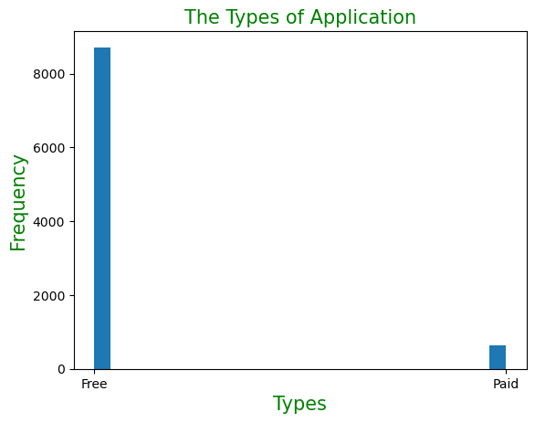

```python
## visuallize the number of types

plt.hist(GAS['Type'], bins=25)

plt.title('The Types of Application', color = 'green', fontsize = 15)
plt.xlabel('Types', color = 'green', fontsize = 15)
plt.ylabel('Frequency', color = 'green', fontsize = 15)
plt.show()
```

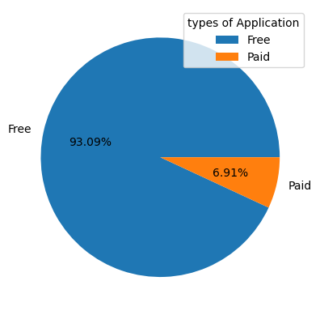

```python
## show a pie chart of types of Application
type_show = ['Free', 'Paid']
Value_count =  [8719,647]
plt.pie(Value_count,labels=type_show,autopct="%2.2f%%")
plt.legend(title='types of Application')
plt.show()
```

```python
## print the top 10 free Apps with Installs in ascending order
GAS.sort_values(by=['Installs','Type','Rating'] , axis = 0 , ascending = False ).head(5)
```

|  | App | Category | Rating | Reviews | Size | Installs | Type | Price | Genres | Last Updated |
| --- | --- | --- | --- | --- | --- | --- | --- | --- | --- | --- |
| 4005 | Clean Master- Space Cleaner & Antivirus | TOOLS | 4.7 | 42916526 | Varies with device | 500,000,000+ | Free | 0 | Tools | August 3, 2018 |
| 7536 | Security Master - Antivirus, VPN, AppLock, Boo... | TOOLS | 4.7 | 24900999 | Varies with device | 500,000,000+ | Free | 0 | Tools | August 4, 2018 |
| 371 | Google Duo - High Quality Video Calls | COMMUNICATION | 4.6 | 2083237 | Varies with device | 500,000,000+ | Free | 0 | Communication | July 31, 2018 |
| 3255 | SHAREit - Transfer & Share | TOOLS | 4.6 | 7790693 | 17M | 500,000,000+ | Free | 0 | Tools | July 30, 2018 |
| 4039 | Google Duo - High Quality Video Calls | COMMUNICATION | 4.6 | 2083237 | Varies with device | 500,000,000+ | Free | 0 | Communication | July 31, 2018 |

### 5.6- What is the number of installs?

```python
## show the installs numbers
GAS['Installs'].unique()
```

```
array(['10,000+', '500,000+', '5,000,000+', '50,000,000+', '100,000+',
       '50,000+', '1,000,000+', '10,000,000+', '5,000+', '100,000,000+',
       '1,000,000,000+', '1,000+', '500,000,000+', '100+', '500+', '10+',
       '5+', '50+', '1+'], dtype=object)
```

```python
GAS['Installs'].value_counts()
```

```
Installs
1,000,000+        1577
10,000,000+       1252
100,000+          1150
10,000+           1010
5,000,000+         752
1,000+             713
500,000+           538
50,000+            467
5,000+             432
100,000,000+       409
100+               309
50,000,000+        289
500+               201
500,000,000+        72
10+                 69
1,000,000,000+      58
50+                 56
5+                   9
1+                   3
Name: count, dtype: int64
```

### 7. Conclusion:-

-We explore the Google App Store dataset and learn more about data attributes then jump into how to visualize the data with Exploratory Data Analysis.

-We saw some basic and advanced level charts of matplotlib like (Pie-chart , Histogram , missino-matrix)

- The questions were answeres within the Analysis: _
1. What is the categories in dataset?
2. What is the top 5 categories?
3. What are the Ratings in dataset?
4. What is top 10 Applications according to Rating?
5. What is best free Applications according to installs?
6. What is the number of installs?

Thank You, Happy to get any suggestions or feedbacks